[O’Hara on GitHub](https://github.com/oharac)

# Process IUCN spp shapes to Mollweide

Compiled on Mon Mar 28 08:16:40 2022 by ohara

```r
knitr::opts_chunk$set(fig.width = 6, fig.height = 4, fig.path = 'Figs/',
                      echo = TRUE, message = FALSE, warning = FALSE)

library(raster)
source('https://raw.githubusercontent.com/oharac/src/master/R/common.R')  ###
library(sf)

source(here('common_fxns.R'))
source('rasterize_fxns.R') ### in same directory as this script

dir_bli <- '/home/shares/ohi/git-annex/globalprep/_raw_data/birdlife_intl/d2021'
dir_shp <- '/home/shares/ohi/git-annex/globalprep/_raw_data/iucn_spp/d2021-3'
```

# 1 Summary

Using a set of IUCN species range maps, rasterize each species to 10 km x 10 km raster using `fasterize`. Use `presence` field from shapefile.

Subpopulation polygons must be identified and rasterized separately from the parent polygon; this must be done by sciname and subpop fields since the polygon IDs are based upon the parent ID.

# 2 Data sources

- IUCN species shapefiles: IUCN. (2021). The IUCN Red List of Threatened Species. Version 2021-3. Retrieved December 2021, from http://www.iucnredlist.org
- BirdLife International shapefiles: BirdLife International and Handbook of the Birds of the World. (2019). Bird species distribution maps of the world. Version 7.0. Available at http://datazone.birdlife.org/species/requestdis
- Bathymetry (GEBCO): Sandwell, D. T., Gille, S. T., & Smith, W. H. F. (2002, June). Bathymetry from Space:Oceanography, Geophysics, and Climate. Retrieved from https://www.gebco.net/

# 3 Methods

## 3.1 Read spp shapes, correct subpop IDs, `fasterize()`, depth clip, save to csv

We will loop over each species in each shapefile and rasterize separately, using `sf` and `fasterize` packages.

- From the full map list, filter to a single shapefile
- Load shapefile using `st_read`, and correct subpop IDs from `shp_iucn_sid` to `iucn_sid`
- Loop over each `iucn_sid` in the shapefile, rasterizing (`fasterize()`) to 10 km<sup>2</sup> resolution, using “presence” field.
  - clip to neritic (<=200 m) and shallow (<=60 m) depth raster if appropriate. Otherwise mask to bathy raster. Since bathy raster was created by masking to area raster, cells with any marine presence will be kept but any non-marine cells will be dropped.
  - Save as .csv, of cell_id and presence
  - use `mclapply()` to speed this up.

```r
worms_spp_names <- read_csv(here('_data/iucn_spp/iucn_to_worms_match.csv')) %>%
  select(iucn_sid, worms_name) %>%
  distinct()

wcol_position <- read_csv(here('_data/traits_grouping/trait_water_col_position.csv')) %>%
  select(sciname = species, wcol_pos = value) %>%
  distinct()

### Manual adds of shallow spp:
spp_shallow <- c(133512)

maps_to_rasterize_all <- read_csv(here('_data/iucn_spp',
                                   'spp_marine_maps_2021-3.csv'),
                              col_types = cols('subpop' = 'c')) %>%
  mutate(shp_file = str_replace(dbf_file, 'dbf$', 'shp')) %>%
  left_join(worms_spp_names, by = 'iucn_sid') %>%
  left_join(wcol_position, by = c('worms_name' = 'sciname')) %>%
  mutate(depth_zone = case_when(str_detect(wcol_pos, 'pelagic')    ~ 'pelagic',
                                str_detect(shp_file, 'bli_marine') ~ 'pelagic',
                                  ### don't clip birds by depth
                                iucn_sid %in% spp_shallow          ~ '< 20 m',
                                TRUE                               ~ max_depth))

### rast_base for cell IDs
ocean_a_mol <- raster(here('_spatial/ocean_area_mol.tif'))
rast_base <- ocean_a_mol %>%
  setValues(1:ncell(.))

### directory for mollweide rasters
dir_mol_rast <- here_anx('spp_maps_mol')

### If some species already processed, remove from the list to process.
# maps_to_clear <- list.files(dir_mol_rast, pattern = 'iucn_spp.+.csv', full.names = TRUE); unlink(maps_to_clear)
maps_done <- list.files(dir_mol_rast, pattern = 'iucn_spp.+.csv') %>%
  str_extract('[0-9]+') %>%
  as.integer()

maps_to_rasterize <- maps_to_rasterize_all %>%
  filter(!iucn_sid %in% maps_done)
```

### 3.1.1 Support functions to help in the processing of all these polygons

These are all defined in `rasterize_fxns.R`:

- `fix_fieldnames()` to adjust the shapefile field names so they match up
- `fix_turtle_polys()` to fix some gaps in turtle polygons before rasterizing
- `match_to_map()` to keep only the polygon features that still need to be rasterized, rather than keeping the overall shapefile
- `clip_to_depth()` to take the resulting raster and mask the result to bathymetric rasters, based on several depth classes, e.g. neritic, shallow
- `buffer_tiny_polys()` to add a small buffer around extremely small polygons. Some polygons are too small (e.g. < 100 km<sup>2</sup>, the size of a raster cell) to be picked up by the rasterization process and result in a zero range. A small buffer will ensure some minimal inclusion for these tiny-ranged species.

```r
rasterize_iucn_map <- function(spp_id) {
  ### spp_id <- spp_ids[1]
  ### spp_id <- 2467 ### also 8097, 13704, 2478, 2477
  ### spp_id <- 172416 ### 0-dist buffer to fix invalid geoms results in loss of area

  ### spp_id <- 192631 ### not POLYGON or MULTIPOLYGON? to fasterize

  j <- which(spp_id == spp_ids)

  msg_stem <- '%s of %s: Processing %s in %s (group %s of %s)...'
  message(sprintf(msg_stem, j, length(spp_ids), spp_id, basename(shp), i, length(shps)))

  spp_shp <- polys_match %>%
    filter(iucn_sid == spp_id)

  spp_shp_processed <- spp_shp %>%
    valid_check() %>%
      ### if invalid geom, fix it
    clip_to_globe() %>%
      ### make sure bounds don't exceed +/- 180
    smoothr::densify(max_distance = 0.1) %>%
      ### add points at half-degree intervals to ensure smooth transform to Mollweide
    st_transform(crs(rast_base)) %>%
      ### transform to Mollweide 10km x 10km resolution
    buffer_tiny_polys()
      ### identify tiny polys, buffer to ensure some representation

  spp_rast <- fasterize::fasterize(spp_shp_processed, rast_base,
                                   field = 'presence', fun = 'min')

  ### clip the rasterized polygons to various depth regimes
  ### depending on species characteristics
  spp_rast_clip <- clip_to_depth(spp_rast, depth_zone = unique(spp_shp_processed$depth_zone))

  # plot(spp_rast, col = 'red'); plot(spp_rast_clip, col = 'green', add = TRUE)

  ### convert to dataframe and write out as a csv:
  spp_present <- data.frame(cell_id  = values(rast_base),
                            presence = values(spp_rast_clip)) %>%
    filter(!is.na(presence))

  if(nrow(spp_present) == 0) {
    message('Species ID ', spp_id, ' resulted in a zero-length dataframe.')
    spp_present <- data.frame(cell_id = -1, presence = NA)
  }

  out_f <- file.path(dir_mol_rast, sprintf('iucn_spp_mol_%s.csv', spp_id))
  write_csv(spp_present, out_f)

  return(NULL)
}
```

```r
message('... Maps to process: ', nrow(maps_to_rasterize))

### These will be used as masks for clip_to_depth().  It's cheating
### to keep these in globalEnv but whatever for now - would be slow to
### load them within the function.
rast_bathy   <- raster(here('_spatial', 'bathy_mol.tif'))
rast_neritic <- raster(here('_spatial', 'bathy_mol_neritic.tif'))
rast_shallow <- raster(here('_spatial', 'bathy_mol_shallow.tif'))

################################################################.
### Loop over each distinct shapefile with species range maps
################################################################.
shps <- maps_to_rasterize$shp_file %>% unique()

for(i in seq_along(shps)) {
  ### i <- 1

  shp <- shps[i]

  message(i, ' of ', length(shps), ': reading ', basename(shp), ' from: \n  ', shp)

  if(!str_detect(shp, 'TURTLES')) {
    ### There's an issue with turtle polys - otherwise just read in the sf
    polys_all <- read_sf(shp, type = 6) %>%
      janitor::clean_names() %>%
      fix_fieldnames()
  } else {
    polys_all <- fix_turtle_polys(shp)
  }

  polys_match <- match_to_map(polys_all, maps_to_rasterize)

  ####################################################################.
  ### In each shapefile, loop over each species ID using mclapply().
  ####################################################################.

  spp_ids <- polys_match$iucn_sid %>%
    sort() %>% unique()

  message('Processing ', basename(shp), ' with ', length(spp_ids), ' species...')

  ### for resolving geometries on the last few, mclapply seems to fail at
  ### st_make_valid() - lapply() also seems to fail - try a simple loop!
  # warning('Using series method instead of parallel method!')
  # for(spp_id in spp_ids) {
  #   rasterize_iucn_map(spp_id)
  # }
  tmp <- parallel::mclapply(spp_ids, mc.cores = 16, FUN = rasterize_iucn_map)

} ### end of for loop over each species group

### test that all are done
maps_done <- list.files(dir_mol_rast, pattern = 'iucn_spp.+.csv') %>%
  str_extract('[0-9]+') %>%
  as.integer()

maps_not_rasterized <- maps_to_rasterize %>%
  filter(!iucn_sid %in% maps_done)

if(nrow(maps_not_rasterized) > 0) {
  stop(nrow(maps_not_rasterized), ' maps failed to rasterize!')
}
```

## 3.2 Make HCAF versions of IUCN spp maps

And save out in one big-ass file like AquaMaps does. This will be useful for Watson data.

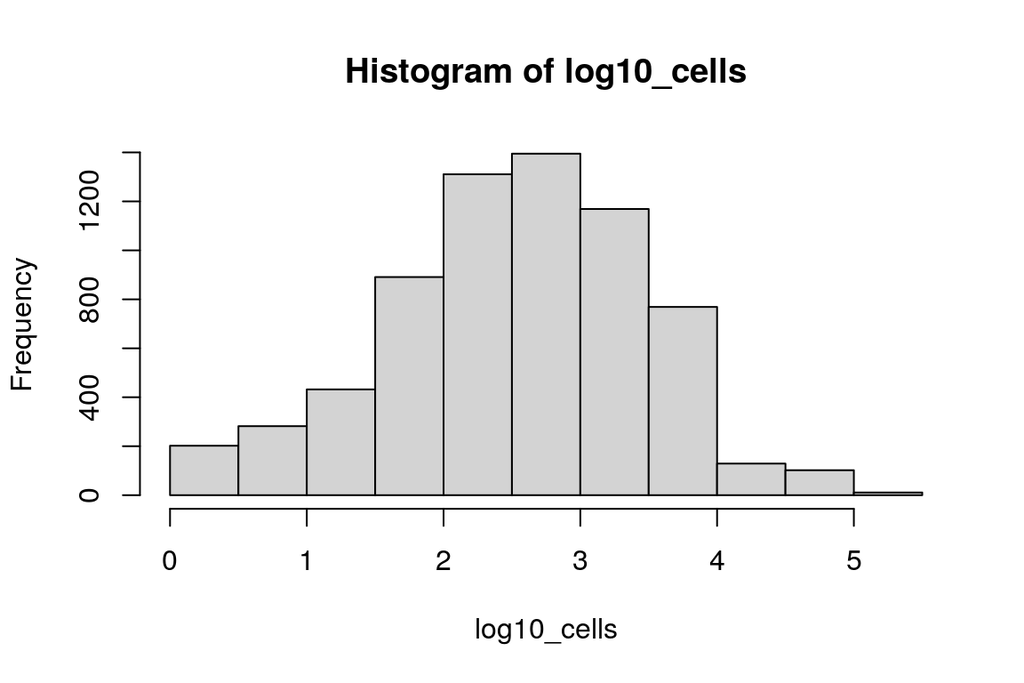

```r
iucn_mol_maps <- list.files(dir_mol_rast, pattern = 'iucn_spp_mol', full.names = TRUE)
loiczid_rast <- raster(here('_spatial/loiczid_mol.tif'))
cell_to_loiczid <- data.frame(loiczid = values(loiczid_rast),
                              cell_id = 1:ncell(loiczid_rast))

tmp_fstem <- here_anx('iucn_spp/tmp/iucn_hcaf_%s.csv')
### maps_to_clear <- list.files(dirname(tmp_fstem), pattern = 'iucn_hcaf', full.names = TRUE)
### unlink(maps_to_clear)

iucn_mol_to_hcaf <- function(f) {
  ### f <- iucn_mol_maps[1]
  sid <- str_remove_all(basename(f), 'iucn_spp_mol_|.csv')
  i <- which(f == iucn_mol_maps)
  tmp_f <- sprintf(tmp_fstem, sid)
  if(!file.exists(tmp_f)) {
    message('Converting Moll map to HCAF for spp ', sid, ' (', i, ' of ', length(iucn_mol_maps), ')')
    x <- read_csv(f, show_col_types = FALSE)
    y <- x %>%
      oharac::dt_join(cell_to_loiczid, by = 'cell_id', type = 'left') %>%
      select(loiczid) %>%
      mutate(prob = 1,
             iucn_sid = as.numeric(sid)) %>%
      distinct()
    write_csv(y, tmp_f)
  }
}

### process all Mollweide IUCN maps to HCAF
tmp <- parallel::mclapply(iucn_mol_maps, mc.cores = 16,
                          FUN = iucn_mol_to_hcaf)

### read in all of 'em, bind, write out to csv
tmp_fs <- list.files(dirname(tmp_fstem), pattern = 'iucn_hcaf', full.names = TRUE)

message('Reading in ', length(tmp_fs), ' temp files for species transformed from moll -> hcaf...')
big_list <- parallel::mclapply(tmp_fs, mc.cores = 16, FUN = read_csv, show_col_types = FALSE)
message('Binding list of temp files...')
big_df <- big_list %>%
  data.table::rbindlist()

write_csv(big_df, here_anx('iucn_spp', 'iucn_spp_hcaf.csv'))

log10_cells <- big_df %>%
  group_by(iucn_sid) %>%
  summarize(n_cells = n_distinct(loiczid)) %>%
  pull(n_cells) %>% log10()

hist(log10_cells)
```